# Day 20 Notebook

```r
input<-read_lines("Day20Sample.txt")
bl<-c(0,which(input==""),length(input)+1)
```

I think this might be a map…

## Part 1

Bring each of these in as a node

```r
## make each tile a list of a tile name & their sides converted into numbers (using binary)
## read the sides both ways (to account for flipping the tile)
## make a list of all t
tilelist<-list()
for(i in 1:(length(bl)-1)){
  tl<-str_sub(input[bl[i]+1],6,-2)
  a<-input[bl[i]+2]
  b<-input[bl[i+1]-1]
  c<-str_flatten(sapply((bl[i]+2):(bl[i+1]-1),function(x){str_sub(input[x],1,1)}))
  d<-str_flatten(sapply((bl[i]+2):(bl[i+1]-1),function(x){str_sub(input[x],nchar(input[x]),nchar(input[x]))}))
  e<-stri_reverse(a)
  f<-stri_reverse(b)
  g<-stri_reverse(c)
  h<-stri_reverse(d)
  sides<-c(a,b,c,d,e,f,g,h)
  sides<-sapply(sides,function(x){str_replace_all(x,"#","1")})
  sides<-sapply(sides,function(x){str_replace_all(x,"\\.","0")})
  sides<-strtoi(sides,2)
  tile<-list(tl,sides)
  tilelist<-c(tilelist,list(tile))}
```

```r
### check for numbers that match on two tiles - use that to create an edgelist

tlmat<-matrix(nrow=0,ncol=2)
for(i in 1:(length(tilelist)-1)){
  for(j in (i+1):length(tilelist)){
    mtch<-any(sapply(tilelist[[i]][2],function(y){y%in%unlist(tilelist[[j]][2])}))
    if(mtch){x<-c(tilelist[[i]][1],tilelist[[j]][1])
    tlmat<-rbind(tlmat,as.character(x))}}}
tlmat<-as.matrix(tlmat)


## use the edgelist to create a graph
tilegraph<-graph_from_edgelist(tlmat,directed=FALSE)
```

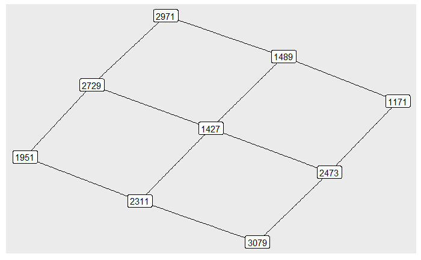

```r
plgr<-ggraph(tilegraph,layout="stress")+
  geom_edge_link()+
  geom_node_label(aes(label=name))
plgr
```

From there, get the corners (the ones with only two connections)

```r
crnrs<-which(sapply(V(tilegraph),function(x){length(neighbors(tilegraph,x))})==2)
crnrs<-V(tilegraph)$name[crnrs]
part1<-prod(as.numeric(crnrs))
part1
```

```
[1] 20899048083289
```

## Part 2

I actually have to put it together.

```r
### flips and rotates square matrices
fandr<-function(m,n){
  y<-nrow(m)+1
  newm<-matrix(NA,ncol=ncol(m),nrow=nrow(m))
  switch(n,
         "1"=for(r in 1:nrow(m)){for(c in 1:ncol(m)){newm[r,c]=m[c,r]}},
         "2"=for(r in 1:nrow(m)){for(c in 1:ncol(m)){newm[r,c]=m[(y-c),r]}},
         "3"=for(r in 1:nrow(m)){for(c in 1:ncol(m)){newm[r,c]=m[c,(y-r)]}},
         "4"=for(r in 1:nrow(m)){for(c in 1:ncol(m)){newm[r,c]=m[(y-c),(y-r)]}},
         "5"=for(r in 1:nrow(m)){for(c in 1:ncol(m)){newm[r,c]=m[(y-r),c]}},
         "6"=for(r in 1:nrow(m)){for(c in 1:ncol(m)){newm[r,c]=m[r,(y-c)]}},
         "7"=for(r in 1:nrow(m)){for(c in 1:ncol(m)){newm[r,c]=m[(y-r),(y-c)]}},
         cat("bad flip"))
newm}
```

I need the tiles/side and also the size of a tile

```r
tilesperside<-sqrt(length(tilelist))
tilesize<-nchar(input[2])
```

Start by getting the first row -

```r
### get the top row
if(length(shortest_paths(tilegraph,from=crnrs[1],to=crnrs[-1],output="vpath")[[1]][[1]])==tilesperside){
  firstrow<-shortest_paths(tilegraph,from=crnrs[1],to=crnrs[-1],output="vpath")[[1]][[1]]$name
}else{firstrow<-shortest_paths(tilegraph,from=crnrs[1],to=crnrs[-1],output="vpath")[[1]][[2]]$name}

nametrix<-matrix(nrow=0,ncol=tilesperside)
nametrix<-rbind(nametrix,unname(firstrow))
nametrix
```

```
     [,1]   [,2]   [,3]
[1,] "1951" "2311" "3079"
```

For all subsequent rows - look at the most recent row and grab the first & last tile find the tiles that are connected to them, but not already in the matrix find the shortest path between them add that to the matrix repeat

```r
for(i in 1:(tilesperside-1)){
  lft<-nametrix[i,1]
  rgt<-nametrix[i,tilesperside]
  nxtlft<-neighbors(tilegraph,v=lft)$name
  nxtlft<-nxtlft[-which(nxtlft%in%nametrix)]
  nxtrgt<-neighbors(tilegraph,v=rgt)$name
  nxtrgt<-nxtrgt[-which(nxtrgt%in%nametrix)]
  nxtrow<-shortest_paths(tilegraph,from=nxtlft,to=nxtrgt,output="vpath")[[1]][[1]]$name
  nametrix<-rbind(nametrix,unname(nxtrow))
}
nametrix
```

```
     [,1]   [,2]   [,3]
[1,] "1951" "2311" "3079"
[2,] "2729" "1427" "2473"
[3,] "2971" "1489" "1171"
```

Put the tiles into a dictionary, so I don’t have to think about them anymore

```r
tiledict<-dict()
for(i in 1:(length(bl)-1)){
  tlk<-str_sub(input[bl[i]+1],6,-2)
  tlv<-matrix(nrow=(bl[2]-bl[1]-2),ncol=nchar(input[2]))
  for(j in 1:nchar(input[2])){tlv[j,]<-unlist(str_split(input[bl[i]+j+1],""))}
  tiledict$set(tlk,tlv)}
```

Function to take in a row of tile numbers and return the expanded matrix

```r
makerow<-function(v,td){
## start with the first two -
  tile1<-td$get(v[1])
  y<-nrow(tile1)+1
  t2edges<-td$get(v[2])
  t2edges<-c(str_flatten(t2edges[1,]),
             str_flatten(t2edges[,1]),
             str_flatten(t2edges[nrow(t2edges),]),
             str_flatten(t2edges[,ncol(t2edges)]),
             str_flatten(rev(t2edges[1,])),
             str_flatten(rev(t2edges[,1])),
             str_flatten(rev(t2edges[nrow(t2edges),])),
             str_flatten(rev(t2edges[,ncol(t2edges)])))
  ### align the corner
  while(!str_flatten(tile1[,nrow(tile1)])%in%t2edges){
    tile1<-fandr(tile1,2)}
  ### outline is the full row of aligned tiles
  outline<-tile1
  ### place the remainder of the pieces
  for(i in 2:length(v)){
    j<-1
    pt<-td$get(v[i])
    reorient<-pt
    while(str_flatten(reorient[,1])!=str_flatten(outline[,ncol(outline)])){
      reorient<-fandr(pt,j)
      j<-j+1}
    outline<-cbind(outline,reorient)}
  outline}
```

use makerow to go through the rows until there’s a full giant matrix of all of the tiles

```r
alltiles<-function(m,td){
  ## as with before, the biggest difficulty is orienting the first row
  r1<-makerow(m[1,],td)
  r2<-makerow(m[2,],td)
  ## check to see if it lines up on the top row or the bottom row
  ### if it does, flip it.  Otherwise, it is oriented correctly
  if(all(r1[1,]==r2[1,])||all(r1[1,]==r2[nrow(r2),])){
    outm<-r1[nrow(r1):1,]
  }else{outm<-r1}
  ### with the top row oriented correctly, line up the remaining rows
  for(j in 2:nrow(m)){
    nxtrow<-makerow(m[j,],td)
    if(all(nxtrow[1,]==outm[nrow(outm),])){outm<-rbind(outm,nxtrow)
    }else if(all(nxtrow[nrow(nxtrow),]==outm[nrow(outm),])){
      outm<-rbind(outm,nxtrow[nrow(nxtrow):1,])
    }else{cat("oops\n")}}
outm}
```

```r
expandedtiles<-alltiles(nametrix,tiledict)
```

now, remove the match rows&columns (if it hasn’t been mentioned - this absolutely 100% needs squares. THI)

```r
dumprows<-c(seq(from=1,to=ncol(expandedtiles),by=tilesize),seq(from=tilesize,to=ncol(expandedtiles),by=tilesize))
wheresnessie<-expandedtiles[-dumprows,-dumprows]
```

It’s (finally) time to look for the monster - first, pull it in

```r
nessie<-read_lines("nessie.txt")
nessiematrix<-matrix(0,nrow=length(nessie),ncol=nchar(nessie[1]))
for(i in 1:length(nessie)){nessiematrix[i,]<-(unlist(str_split(nessie[i],"")))}
nessiesonar<-which(nessiematrix=="#",arr.ind=TRUE)
### we want the offset from start
nessiesonar<-nessiesonar-c(1,1)
```

Then check against every orientation of the map

```r
 workingmap<-wheresnessie
 ncount<-0
 i<-0
 while(ncount==0){
   for(r in 1:(nrow(workingmap)-nrow(nessiematrix)+1)){
     for(c in 1:(ncol(workingmap)-ncol(nessiematrix)+1)){
       chck<-sapply(1:nrow(nessiesonar),function(x){
         ### get the list of offset spaces
         y<-nessiesonar[x,]+c(r,c)
         ### get all of those places on the map
         y<-workingmap[y[1],y[2]]
       y})
       if(all(chck=="#")){ncount<-ncount+1}}
     #cat(paste(chck),"\n")
     }
 i<-i+1
 ### if no monsters found, flip the main map
 workingmap<-fandr(wheresnessie,i)}
 ### if the monsters do not overlap, this will give the answer
 ### Because this was true for me, I'm not solving the bigger picture
 length(which(wheresnessie=="#"))-ncount*15
```

```
[1] 273
```